# Box cox transformation

Box cox transformation

In order to perform ordinary least sqaures regression, there are certain assumptions that need to be considered before building a modeling. Assumptions regarding residuals, such as normal distribution, constant variance i.e homoscadaticity need to be checked while building a model. However, there will be times when the assumptions of OLS are violated by data. In such instances data transformation can be employed to transform data from non-linear distribution to linear distribution. In this post we will look at one such technique called “Box Cox” transformation.

```r
library(readr) # importing csv files
library(MASS) # Boxcox function
library(car) # qqPlot function
library(moments) # skeweness and kurtosis functions
```

```r
TGT <- read_csv("C:/Users/welcome/Downloads/TGT.csv")

attach(TGT)
```

## Data preparation

1. As the class of TAT is integer, it is converted to numeric
2. Grades “ASE1”, “ASE2”, “ASE3”,“ASE4”, “ASE5” are changed to 1, 2, 3, 4 & 5 respectively, and class of Grade is converted from character to numeric.

```r
TGT[,"TAT"] <- as.numeric(TAT) # convert to num


TGT[which(GRADE == 'ASE1'), "GRADE"] <- 1

TGT[which(GRADE == 'ASE2'), "GRADE"] <- 2

TGT[which(GRADE == 'ASE3'), "GRADE"] <- 3

TGT[which(GRADE == 'ASE4'), "GRADE"] <- 4

TGT[which(GRADE == 'ASE5'), "GRADE"] <- 5

TGT[,"GRADE"] <- as.numeric(TGT$GRADE)
```

## Model fitting ( Before transformation)

TAT is regressed with GRADE with out any data tranformation.

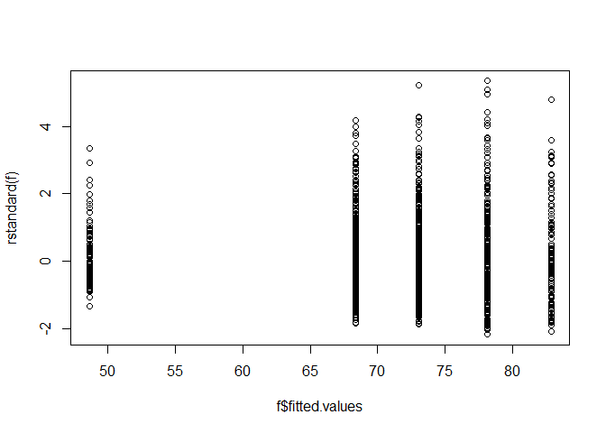

```r
f <- lm(TAT ~ as.factor(GRADE))

plot(f$fitted.values,  rstandard(f)) # Examine raw residuals  vs fitted values
```

From the above plot, it appears that there is a trend in the residuals, which takes the shape of an outward funnel.

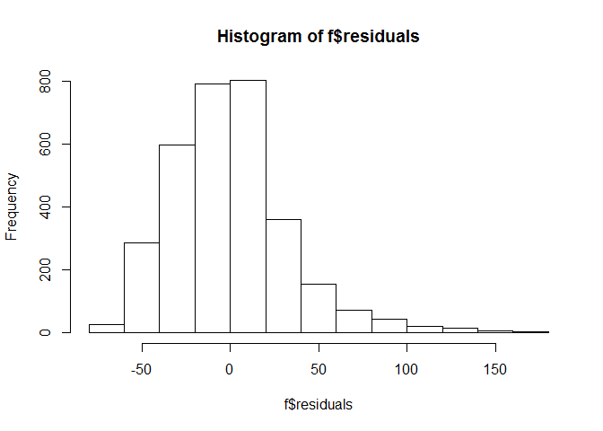

```r
hist(f$residuals) # examine histogram of raw residuals
```

Histogram indicate distribution of raw residuals is postively skewed.

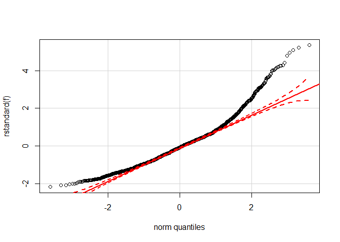

```r
qqPlot(rstandard(f)) # examine quantile-quantile plot for raw residuals
```

```r
skewness(f$residuals)
```

```
## [1] 1.076633
```

```r
kurtosis(f$residuals)
```

```
## [1] 5.420123
```

## Estimation of likelihood function

```r
b <- boxcox(TAT ~ GRADE)
```

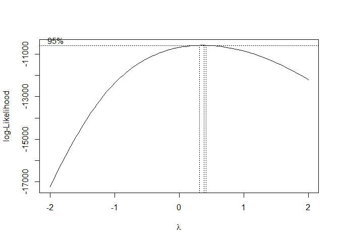

```r
lambda <- b$x # lambda values

lik <- b$y # log likelihood values for SSE

bc <- cbind(lambda, lik) # combine lambda and lik

sorted_bc <- bc[order(-lik),] # values are sorted to identify the lambda value for the maximum log likelihood for obtaining minimized SSE

head(sorted_bc, n = 10)
```

```
##          lambda       lik
##  [1,] 0.3838384 -10576.90
##  [2,] 0.3434343 -10576.99
##  [3,] 0.4242424 -10579.12
##  [4,] 0.3030303 -10579.44
##  [5,] 0.4646465 -10583.62
##  [6,] 0.2626263 -10584.28
##  [7,] 0.5050505 -10590.36
##  [8,] 0.2222222 -10591.55
##  [9,] 0.5454545 -10599.31
## [10,] 0.1818182 -10601.31
```

The lambda value for for the maximum log likeihood for obtaining minimized SSE is 0.38( also can be seen in the box cox plot above)

## Model fitting (After transformation)

After identifying the lambda value, which is 0.38, lets fit the model with the transformed data.

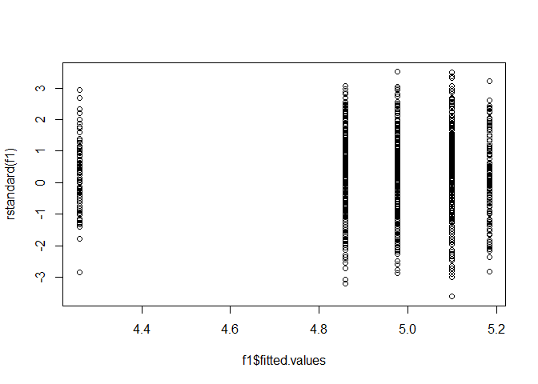

```r
f1 <- lm(TAT^(0.38) ~ as.factor(GRADE))

plot(f1$fitted.values,  rstandard(f1)) # Examine raw residuals vs fitted values
```

The distribution of residuals around the fitted line has improved from the previous model. Nearly close to constant variance.

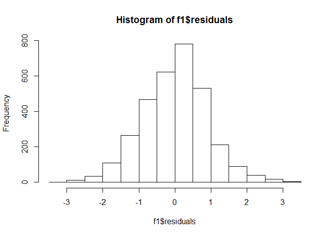

```r
hist(f1$residuals) # examine histogram of raw residuals
```

Histogram indicate distribution of raw residuals is very close to normal distribution.

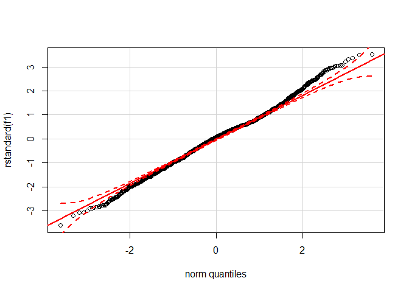

```r
qqPlot(rstandard(f1)) # examine quantile-quantile plot for raw residuals
```

```r
skewness(f1$residuals)
```

```
## [1] -0.00364926
```

```r
kurtosis(f1$residuals)
```

```
## [1] 3.373519
```

The adjusted R square value has improved from model fitted with untransformed data to model fitted with transformed data.

```r
adj_rsq1 <- summary(f)$adj.r.squared

adj_rsq2 <- summary(f1)$adj.r.squared

cat("Adjusted R-Square (before transformation):", adj_rsq1, "Adjusted R-Square (after transformation):", adj_rsq2, sep = "\n")
```

```
## Adjusted R-Square (before transformation):
## 0.04481049
## Adjusted R-Square (after transformation):
## 0.04722951
```